# Matrix Operations Demo

One thing in particular that I have always appreciated about R is how elegantly it handles matrix operations. I have never gotten much joy from calculating a determinant by hand, but R makes life much easier in this particular regard.

While SAS also has great capabilities with matrix operations, its equivalent offering (`PROC IML`) is an add-on component that is not included as part of the base SAS package. With R, you don’t even need to load in a special package; matrix operations work in a “batteries included” way with the base software.

Let’s have a little bit of fun with a very simple demonstration of matrix operations in R.

# Demo Data

Let’s create three objects. We will name them `y`, `x1`, and `x2`. As you can probably guess by their names, we’ll use these in a linear regression model eventually.

```r
y <- c(222, 217, 189, 263, 172, 129, 166, 271, 207, 201)
x1 <- c(115, 114, 73, 127, 87, 65, 82, 115, 95, 123)
x2 <- c(114, 106, 89, 142, 79, 68, 97, 116, 106, 103)

# Combine these into a data frame to simplify some downstream steps
df <- data.frame(y = y, x1 = x1, x2 = x2)
```

# Explore

Let’s use `ggplot2` to explore these three objects. I’m also going to use `GGally` here to help with creating a scatter plot matrix.

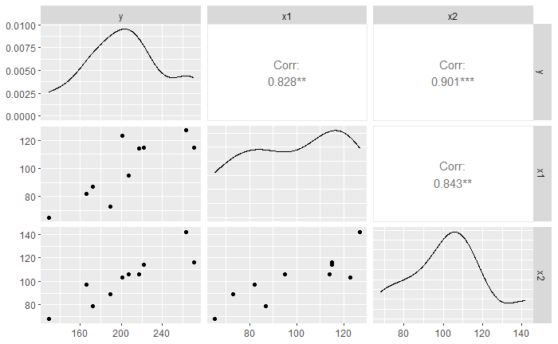

```r
# Load packages
require(ggplot2)
require(GGally)

# Create plot
ggpairs(
    df,
    diag = list(continuous = "densityDiag"),
    upper = list(continuous = "cor"),
    lower = list(continuous = "points")
)
```

# Fit a Linear Regression Model

Let’s use the `lm` function to predict values of `y` from `x1` and `x2`.

```r
fit_lm <- lm(y ~ x1 + x2, data = df)
summary(fit_lm)
```

```
Call:
lm(formula = y ~ x1 + x2, data = df)

Residuals:
    Min      1Q  Median      3Q     Max
-22.216 -11.210  -3.422   6.064  39.653

Coefficients:
            Estimate Std. Error t value Pr(>|t|)
(Intercept)   8.1153    34.3406   0.236    0.820
x1            0.4637     0.5710   0.812    0.444
x2            1.4647     0.6085   2.407    0.047 *
---
Signif. codes:  0 ‘***’ 0.001 ‘**’ 0.01 ‘*’ 0.05 ‘.’ 0.1 ‘ ’ 1

Residual standard error: 20.34 on 7 degrees of freedom
Multiple R-squared:  0.8277,    Adjusted R-squared:  0.7784
F-statistic: 16.81 on 2 and 7 DF,  p-value: 0.002125
```

# Use Matrix Operations to Calculate the Coefficients

When I was in graduate school, I practically had this formula burned into my brain.

$$\hat{\boldsymbol{\beta}} =
(\mathbf{X}'\mathbf{X})^{-1}\mathbf{X}'\mathbf{y}$$

Let’s redo the `lm` step the hard way, this time using matrix operations. First, let’s set up matrix objects that I will name `Y` and `X`. Because we want our regression model to have an intercept, I will add a column of 1s to the far left side of the `X` matrix.

```r
# Create matrixes
Y <- cbind(y = y)
X <- cbind(int = 1, x1 = x1, x2 = x2)

# Display them
print(Y)
```

```
        y
 [1,] 222
 [2,] 217
 [3,] 189
 [4,] 263
 [5,] 172
 [6,] 129
 [7,] 166
 [8,] 271
 [9,] 207
[10,] 201
```

```r
print(X)
```

```
      int  x1  x2
 [1,]   1 115 114
 [2,]   1 114 106
 [3,]   1  73  89
 [4,]   1 127 142
 [5,]   1  87  79
 [6,]   1  65  68
 [7,]   1  82  97
 [8,]   1 115 116
 [9,]   1  95 106
[10,]   1 123 103
```

Now, let’s calculate the model coefficients using the formula above. I won’t go over all matrix operators in R here, but I will point out that `%*%` indicates matrix multiplication, `t()` transposes a matrix, and `solve()` is the inverse of a matrix.

```r
B <- solve(t(X) %*% X) %*% t(X) %*% Y
print(B)
```

```
            y
int 8.1153453
x1  0.4636684
x2  1.4647381
```

Let’s compare back to the coefficients we obtained from `lm`.

```r
print(fit_lm$coefficients)
```

```
(Intercept)          x1          x2
  8.1153453   0.4636684   1.4647381
```

As we can see here, the results we obtained from our manual calculations match what is produced in by the `lm` function.